# Gaussian and Student t Copula Time Series Models for Count Data

The `gctsc` package provides fast and scalable tools for fitting **Gaussian and Student t copula models for count time series**, supporting a wide range of discrete marginals:

- Poisson
- Negative Binomial
- Binomial
- Beta Binomial
- Zero-Inflated Poisson (ZIP)
- Zero-Inflated Binomial (ZIB)
- Zero-Inflated Beta-Binomial (ZIBB)

These models are constructed from a latent **ARMA process** combined with a discrete marginal distribution. Likelihood evaluation requires computing multivariate probabilities under Gaussian or Student–t dependence structures.

The package provides several likelihood approximation methods:

- **TMET** — Time Series Minimax Exponential Tilting
- **GHK** — Geweke–Hajivassiliou–Keane simulator
- **CE** — Continuous Extension approximation

In addition, the package offers:

- Simulation of count time series with ARMA latent structure
- Maximum likelihood estimation using the above likelihoods
- Residual diagnostic tools
- One-step-ahead prediction

A key feature of the package is the TMET method, which exploits the conditional structure of ARMA processes to compute likelihood approximations efficiently even for long time series. The package also includes the classical GHK simulator and the Continuous Extension approximation for comparison.

This vignette illustrates the main functionality of the `gctsc` package, including simulation, likelihood approximation, model fitting, diagnostics, and prediction for copula-based count time series models.

## Installation

The package can be installed from CRAN using

```r
install.packages("gctsc")
```

The development version is available at

```r
remotes::install_github("QNNHU/gctsc")
```

## Package overview

The package provides tools for simulation, likelihood evaluation, estimation, diagnostics, and prediction for copula-based count time series models with Gaussian or Student–t copula dependence.

The package implements several likelihood approximation methods, including Time Series Minimax Exponential Tilting (TMET), the classical Geweke–Hajivassiliou–Keane (GHK) simulator, and the Continuous Extension (CE) approximation.

### Main functions

| Function | Description |
| --- | --- |
| `sim_*()` | Simulate copula count time series with latent ARMA dependence |
| `pmvn_*()` / `pmvt_*()` | Compute multivariate rectangle probabilities for Gaussian and Student–t copulas |
| `gctsc()` | Fit Gaussian or Student–t copula count time series models |
| `predict()` | Compute one-step-ahead predictive distributions and moments |
| `plot()` | Produce residual diagnostic plots |
| `summary()` | Display parameter estimates and model fit statistics |

The following sections illustrate the main functionality of the package, including simulation, likelihood approximation, model estimation, diagnostics, and prediction.

### Example 1: Simulating Poisson AR(1) counts under a Gaussian copula

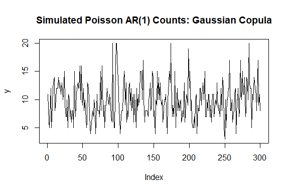

```r
n  <- 300
mu <- 10
phi <- 0.2
arma_order <- c(1, 0)
tau <- c(phi)

sim_data <- sim_poisson(
  mu = mu,
  tau = tau,
  arma_order = arma_order,
  nsim = n,
  family = "gaussian",
  seed = 7
)

y <- sim_data$y
plot(y, type = "l", main = "Simulated Poisson AR(1) Counts: Gaussian Copula")
```

### Example 2: Simulating Poisson AR(1) counts under a Student–t copula

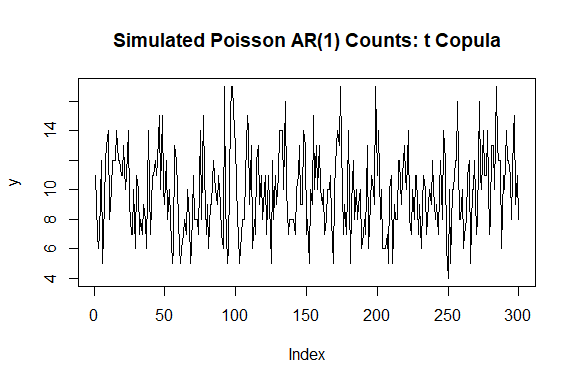

```r
n  <- 300
mu <- 10
phi <- 0.2
arma_order <- c(1, 0)
tau <- c(phi)

sim_data <- sim_poisson(
  mu = mu,
  tau = tau,
  arma_order = arma_order,
  nsim = n,
  family  = "t",
  df = 5,
  seed = 7
)

y <- sim_data$y
plot(y, type = "l", main = "Simulated Poisson AR(1) Counts: t Copula")
```

### Example 3: Simulating Zero–Inflated Beta–Binomial (ZIBB) AR(1) Count Time Series

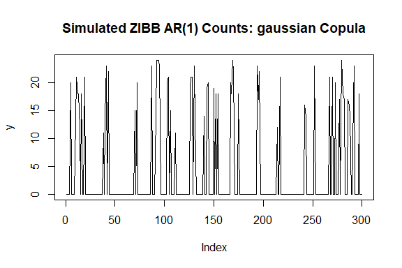

```r
n <- 300
phi <- 0.5
tau <- c(phi)

beta_0 <- 1.2
prob   <- plogis(beta_0)
rho    <- 0.1
pi0    <- 0.8
size   <- 24

set.seed(7)
sim_data <- sim_zibb(prob = prob * rep(1,n),
                     rho = rho, pi0 = pi0,
                     size = size, tau = tau,
                     arma_order = c(1,0),
                     family = "gaussian",
                     nsim = n)
y <- sim_data$y

plot(y, type = "l", main = "Simulated ZIBB AR(1) Counts: gaussian Copula")
```

### Example 4: Likelihood approximation (TMET vs GHK vs CE)

```r
n <- 300
mu <- 10
phi <- 0.5
theta <- 0.2
arma_order <- c(1,1)
tau <- c(phi, theta)

# Simulate Poisson count data
sim_data <- sim_poisson(mu, tau, arma_order, nsim = n, seed = 1)
y <- sim_data$y

# Compute bounds for truncated MVN using marginal object
marg <- poisson.marg()
lower <- qnorm(ppois(y - 1, lambda = mu))
upper <- qnorm(ppois(y, lambda = mu))

# Likelihood approximation
llk_tmet <- pmvn_tmet(lower, upper, tau, od = arma_order, pm = 30, QMC = TRUE)
llk_ghk  <- pmvn_ghk(lower, upper, tau, od = arma_order, QMC = TRUE)
llk_ce  <- pmvn_ce(lower, upper, tau, od = arma_order)

c(TMET = llk_tmet, GHK = llk_ghk, CE = llk_ce)
```

```
#>      TMET       GHK        CE
#> -704.8721 -704.8980 -704.8964
```

### Example 4: Fitting a Gaussian Copula Count Model

```r
n <- 300
mu <- 10
phi <- 0.5
theta <- 0.2
arma_order <- c(1,1)
tau <- c(phi, theta)

# Simulate Poisson count data
sim_data <- sim_poisson(mu, tau, arma_order, nsim = n, seed = 1, family ="gaussian")
y <- sim_data$y

fit <- gctsc(
  formula  = y ~ 1,
  marginal = poisson.marg(),
  cormat   = arma.cormat(p = 1, q = 1),
  method   = "CE", family ="gaussian"
)

summary(fit)
```

```
#>
#> --- Summary of Copula Time Series Model ---
#> Call:
#>  gctsc(formula = y ~ 1, marginal = poisson.marg(), cormat = arma.cormat(p = 1,      q = 1), method = "CE", family = "gaussian")
#>
#> Marginal Model Coefficients:
#>                Estimate Std. Error z value Pr(>|z|)
#> mu_(Intercept)  10.1915     0.3254   31.32   <2e-16 ***
#>
#> Copula (Dependence) Coefficients:
#>     Estimate Std. Error z value Pr(>|z|)
#> ar1  0.45000    0.07367   6.108 1.01e-09 ***
#> ma1  0.29137    0.09428   3.090    0.002 **
#> ---
#> Signif. codes:  0 '***' 0.001 '**' 0.01 '*' 0.05 '.' 0.1 ' ' 1
#>
#> Model Fit Statistics:
#>   Log-likelihood: -704.2735
#>   AIC:             1414.5469
#>   BIC:             1425.6583
```

### Example 5: Residual diagnostics

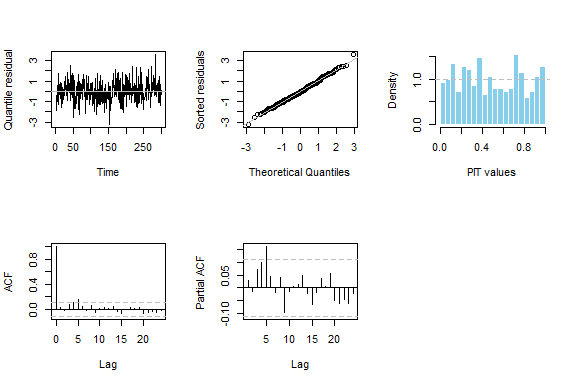

```r
oldpar <- par(no.readonly = TRUE)

par(mfrow = c(2,3))
plot(fit)
```

```r
par(oldpar)
```

### Example 6: One-step-ahead prediction

```r
prediction <- predict(
  fit,
  y_obs   = 10
)

prediction
```

```
#> $mean
#> [1] 9.392475
#>
#> $median
#> [1] 9
#>
#> $mode
#> [1] 9
#>
#> $variance
#> [1] 5.825961
#>
#> $p_y
#>  [1] 7.000283e-07 2.817442e-05 3.676383e-04 2.476266e-03 1.041904e-02
#>  [6] 3.041130e-02 6.580845e-02 1.105407e-01 1.490679e-01 1.655974e-01
#> [11] 1.546547e-01 1.234425e-01 8.536274e-02 5.172959e-02 2.774009e-02
#> [16] 1.327464e-02 5.710337e-03 2.222379e-03 7.869848e-04 2.548670e-04
#> [21] 7.582997e-05 2.081307e-05 5.289583e-06 1.249034e-06 2.748826e-07
#> [26] 5.654337e-08 1.089990e-08 1.973911e-09 3.365726e-10 5.414872e-11
#> [31] 8.235819e-12 1.186395e-12 1.484766e-13 8.687693e-14 8.687693e-14
#>
#> $lower
#> [1] 5
#>
#> $upper
#> [1] 14
#>
#> $CRPS
#> [1] 0.6296832
#>
#> $LOGS
#> [1] 1.86656
```

### Example 7: Fitting a t Copula Count Model

```r
n <- 100
mu <- 10
phi <- 0.5
theta <- 0.2
arma_order <- c(1,1)
tau <- c(phi, theta)

# Simulate Poisson count data
sim_data <- sim_poisson(mu, tau, arma_order, nsim = n, family = "t", df= 15, seed = 1)
y <- sim_data$y

fit <- gctsc(
  formula  = y ~ 1,
  marginal = poisson.marg(),
  cormat   = arma.cormat(p = 1, q = 1),
  method   = "CE", family ="t", df= 15
)

summary(fit)
```

```
#>
#> --- Summary of Copula Time Series Model ---
#> Call:
#>  gctsc(formula = y ~ 1, marginal = poisson.marg(), cormat = arma.cormat(p = 1,      q = 1), method = "CE", family = "t", df = 15)
#>
#> Marginal Model Coefficients:
#>                Estimate Std. Error z value Pr(>|z|)
#> mu_(Intercept)   9.8799     0.5222   18.92   <2e-16 ***
#>
#> Copula (Dependence) Coefficients:
#>     Estimate Std. Error z value Pr(>|z|)
#> ar1   0.4728     0.1409   3.355 0.000793 ***
#> ma1   0.3067     0.1628   1.884 0.059518 .
#> ---
#> Signif. codes:  0 '***' 0.001 '**' 0.01 '*' 0.05 '.' 0.1 ' ' 1
#>
#> Model Fit Statistics:
#>   Log-likelihood: -217.1995
#>   AIC:             440.3991
#>   BIC:             448.2146
```